# Exam QFI

Steven Cheng

2023-05-03

# A Note About Notations

Consider moving this as a footnote

In the book:

- $dF_t$ represents the total change in the derivative price $F(S_t, t)$.
- $F_t$ represents the partial derivative of $F(S_t, t)$ with respect to t.
- In the notes, I attempt to make things more clear by denoting the the first order derivative with respect to t written as $F'_t$ and second order as $F''_t$

# Financial Derivatives

**Financial Derivatives** are securities that derive their value from cash markets. In Ingersoll’s definition, a financial contract is a derivative security.

**Cash and Carry Markets**: Gold, silver, T-bonds. The idea is to borrow cash, buy asset, and hold until expiration.

**Forward Contract**: obligation to buy/sell an asset at a specified price at a future date. if cash price is higher at expiration then forward, and long position make a profit.

| Characteristic | Futures | Forwards |
| --- | --- | --- |
| Mark to Market | Yes | No |
| Settlement | Daily | Upon Maturity |
| Margin System | Yes | No |
| Trading | Exchanges | OTC |
| Types | Standardized | Custom |
| Flexibility | Less | More |
| Liquidity | More | Less |
| Counterparty Risk | Less | More |

**Repurchase Agreement (REPO)**: A transaction in which one party sells a security in return for cash, with an agreement to repurchase the security at an agreed upon price at a future date.

**Options**:

- European: The right to buy $S_t$ at strike k. This right may be excercised at time T. Where $S_T <K$ is out the money and $S_T > K$ is in the money.
  $$C_T = \max(S_T -K)$$

**Swaps**: Exchange of one set of cashflows for another. Swaps are simultaneous and can involve curruncies, interst rates, etc. Swaps can be priced through forwards. Cancelable swaps allow the right to cancel swap contracts.

**Arbitrage**: Taking simultaneous positions so that it guarantees a riskless profit higher than the risk-free rate. Let $d_{ij}$ be the number of units of account paid by one unit of security i in state j. Rows represent asset, columns represent state (interest, conflict, recession, etc…)

$$\text{Asset Values} = S_T =
\begin{bmatrix}
S_1(t) \\
S_2(t) \\
\vdots \\
S_n(t)
\end{bmatrix}$$

$$D_t = \begin{bmatrix}
d_{11} & d_{12} & \cdots & d_{1k} \\
d_{21} & d_{22} & & d_{2k} \\
\vdots & & \ddots & \vdots\\
d_{i1} & d_{i2} & \cdots & d_{ik}
\end{bmatrix}$$

$$\text{example of a 2 state portfolio with cash, security, and call}\\
\begin{bmatrix}
(1+r\Delta) & (1+r\Delta) \\
S_1(t + \Delta) & S_2(t + \Delta) \\
C_1(t + \Delta) & C_2(t + \Delta)
\end{bmatrix}$$

No arbitrage possibility exists iff:

$$\begin{bmatrix}
1 \\ S(t) \\ C(t)
\end{bmatrix}
=
\begin{bmatrix}
(1+r\Delta) & (1+r\Delta) \\
S_1(t + \Delta) & S_2(t + \Delta) \\
C_1(t + \Delta) & C_2(t + \Delta)
\end{bmatrix}
\begin{bmatrix}
\psi_1 \\ \psi_2
\end{bmatrix}$$

$\psi_n$ represents the risk neutral probability discounted at the risk free rate and:

$$\sum_i^n \psi_i = v = \frac{1}{1+r}
\rightarrow \sum_i^n \psi_i \cdot (1+r) = \sum_i^n Q_i = 1$$

**Binomial Tree Pricing**: A method of valuing options. Steps to determine option value is to first determine the value at expiration, then work backwards each step until the current price is obtained.

$$C_T = \frac{1}{1+r}[Q_{up} C_{t+\Delta}^{up} + Q_{down}
C_{t+\Delta}^{down}]$$

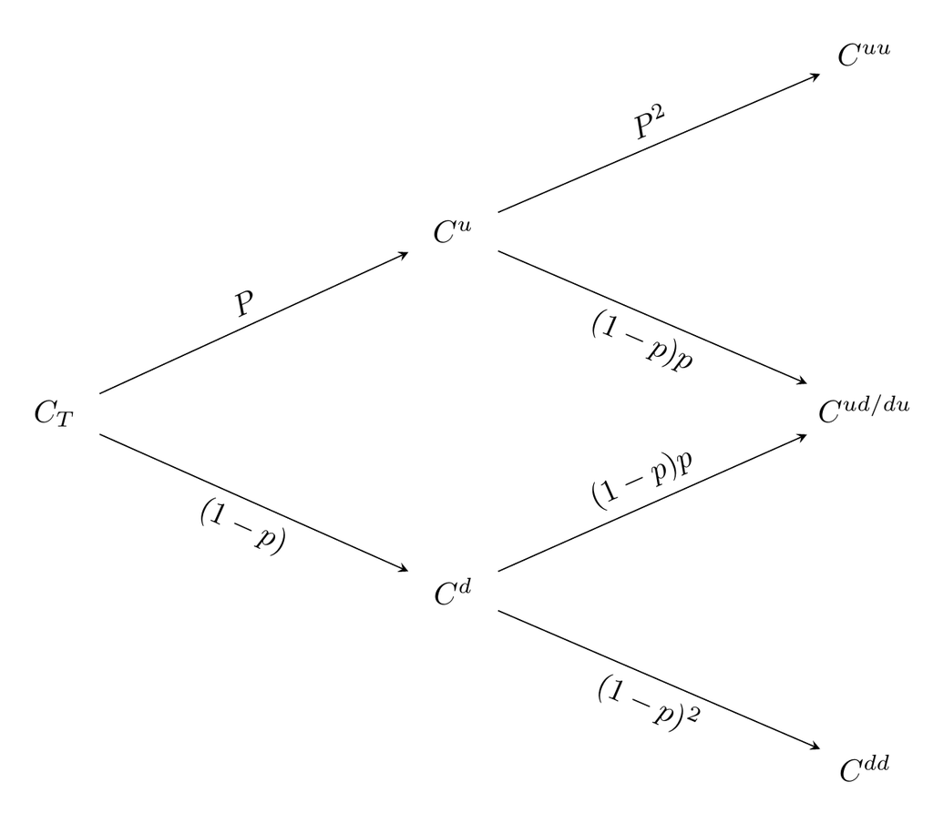

If we assume dividends are paid as a % of $S_{t+\Delta}$. Then by arbitrage:
$$\begin{bmatrix}
1 \\ S(t) \\ C(t)
\end{bmatrix} =
\begin{bmatrix}
B^u_{t+\Delta} & B^d_{t+\Delta} \\
S^u_{t+\Delta} + d_tS^u_{t+\Delta} & S^d_{t+\Delta} +
d_tS^d_{t+\Delta} \\
C^u_{t+\Delta} & C^d_{t+\Delta}
\end{bmatrix}
\begin{bmatrix}
\psi_1 \\ \psi_2
\end{bmatrix}\\
E^Q[\frac{S_{t+\Delta}}{S}] = \frac{1+r\Delta}{1+d\Delta} \approx
1+(r-d)\Delta \\
E^Q[\frac{C_{t+\Delta}}{C}] = 1+r\Delta$$
Under risk-neutral expectations. S grows below the risk free rate at r-d while the call option is expected to return r. For foreign currencies, replace d with the foreign savings interest rate rf.

## Risk Neutral Pricing Summary

- Obtain a model to track dynamics of underlying
- Calculate how derivative asset price relates to the price of the underlying asset ast expiration or other boundaries
- Obtain risk adjusted probabilities
- Calculate expected payoffs of derivative at expiration using risk adjusted probabilities
- Discount this expectation using the risk-free return.

# Math of Financial Derivatives

### Basics

$$1 + 1 + \frac{1}{2!} + \frac{1}{3!} \dots = e \\
e^{x+y} = e^x \cdot e^y\\
\frac{d}{dx} e^{kx} = ke^{kx}$$

**Function of Bounded Variation**

$$V_0 = \max{\sum^n_{i=1}|f(t_i) - f(t_{i-1})|} < \infty$$

**Definition of a derivative**

$$f'_x = \lim_{\Delta \rightarrow 0} \frac{f(x+\Delta) - f(x)}{\Delta}
\\
f_x'' = \frac{f_x'(x+\Delta) - f_x'(x)}{\Delta} \approx
\frac{f(x+\Delta) - 2f(x) + f(x-\Delta)}{\Delta^2}$$

**First order approximations of functions**

$$f(x+\Delta) \approx f(x) + f'_x(\Delta)$$

**Chain Rule**

$$y_t = f(g(t)) \text{ and } x_t = g(t) \\
\frac{dy}{dt} = \frac{df(g(t))}{dg(t)} \cdot\frac{dg(t)}{dt}$$

**Probability Basics**

- $\omega = \text{particular state of the world}$
- $\Omega = \text{all possible states of the world}$
- $I = \text{set of all possible events}$
- $P(A) \geq 0$ for any $A \in I$
- $\int_{A \in I} dP(A) = 1$
- distribution function: $G(x) = P(X \leq x)$

**Moments**

- Expectation first moment: $E(X) = \int_{-\infty}^{\infty} xf(x)dx$
- Second moment is variance
- Third moment is skew
- Fourth moment is kurtosis

**Normal Distribution**

$$X \sim N(\mu, \sigma^2)$$

- PDF: $f(x) = \frac{1}{\sigma \sqrt{2\pi}}e^{-\frac{1}{2}(\frac{x-\mu}{\sigma})^2}$
- $E(X) = \mu$
- $V(X) = \sigma^2$
- skew = $E((X - E(X))^3) = 0$
- kurtosis = $E[(\frac{x-\mu}{\sigma})^4]$

### Intermediate

**Riemann Integral**

Given max $|t_i - t_{i+1}| \rightarrow 0$, the Riemann integral will be defined by the limit

$$\sum_{i=1}^n f(\frac{t_i + t_{i-1}}{2})(t_i + t_{i-1}) \rightarrow
\int_0^T f(s)ds$$

**Integration by Parts**

$$d(f(t) \cdot h(t)) = f'(t)h(t) + f(t)h'(t) \Rightarrow f(T)h(T)
-f(0)h(0) - \int_0^Tf(t)h'(t)dt$$

**Partial vs Total Differentials**

Let $C_t = F(S_t,t)$

$$\frac{\partial F(S_t,t)}{\partial S_t} = F_s : \text{Partial Derivative}
\\
df = F_sdS_t + F_tdt : \text{Total Differential}$$

**1D Taylor Series**

Let f(x) be an infinitely differentiable function of $x \in \bR$. Expanding around point $x_0$

$$f(x) = f(x_0) + f'_(x_0)(x-x_0) +
\frac{1}{2}f''_x(x_0)(x-x_0)^2 + \dots = \sum_{n=0}^\infty
\frac{f^n_x(x_0)}{n!}(x-x_0)^n$$

**Ordinary Differential Equations**

$$dB_t = -r_tB_tdt \Rightarrow B_t = e^{\int_0^tr_udu}$$

**Conditional Expectation**

- $I_{t_0} \subseteq I_{t_1} \subseteq \dots \subseteq I_{t_k}$
- A family $I_t$ satisfying the above property is called filtration.
- $I_t$ contains the information that we condition on
- $P(|X-X_0| \leq \frac{dx}{2} \approx f(x_0)dx$
- $E(S_t | I_u) = \int_{-\infty}^\infty S_t f(S_t | I_u) dS_t, u < t$
- Linearity property: $E[S_t + F(t)] = E[S_t] + E[F(t)]$

# Pricing Methods

1. Arbitrage on financial assets which are martingales. Known as the method of equivalent martingales.
2. Construct a risk-free portfolio to obtain a partial-differential equation (PDE) that is implied by the lack of arbitrage opportunities.
   - Gold Example:
     - Portfolio 1: Borrow money, buy gold, hold until expiration. Pay back money at time T
     - Portfolio 2: Buy forward contract (cash exchanged at T to receive gold).
     - $F(S_t,t) = \underbrace{S_te^{r_t(T-t)}}_{\text{loan repayment}} + \underbrace{c(T-t)}_{\text{storage costs}}$
   - Delta Hedging Example:
     - Construct a risk free portfolio by combining loans, a long call, and short $\Delta$ shares. (requires continuous delta hedging)
     - $\frac{\partial F(S_t,t)}{\partial S_t} = F(s) = \Delta$

**Binomial Models**

- $Pr(\Delta F(t) = a \sqrt{\Delta} = p)$
- Assume F(t) is the real time price, and that over a small time interval there is either an uptick or downtick.
- $E[\Delta F(t) = ap\sqrt{\Delta} - a(1-p)\sqrt{\Delta} ]$
- $V[\Delta F(t)] = 4a^2\Delta p(1-p)$

**Poisson Distribution**

- Unpredictable occurrence at times t = 1,2,3.
- Jumps are assumed to be independent and of the same size.
- In a given small interval, the probability of observing more than 1 jump is negligible.
- Denote $N_t$ as number of jumps up to time t.
- Let $\Delta$ be a small time interval.
- $\lambda$ = positive constant called intensity
- $\Delta N_t = 1$ if there is a jump, otherwise it’s 0
- $P(\Delta N_t =1) \approx \lambda N, P(\Delta N_t = 0) \approx 1-\lambda N, P(\Delta N_t = n) = \frac{e^{-\lambda\Delta}(\lambda \Delta)^N}{n!}$

**Markov Processes**

A discrete time process ${X_1, \dots ,X_t}$ with joint probability distribution function $F(x_1,\dots, x_t)$ is said to be a Markov Process iff:

$$Pr(X_{t+s} \leq X_{t+s} | X_1, \dots, X_t) = Pr(X_{t+s} \leq X_{t+s}
| X_t)$$

Where s > 0, $P(. | I_t)$ is the probability conditional on the information set $I_t$. Basically saying that the probability of the next state is only conditional on the state prior to the event.

## Convergence

**Almost Sure Convergence**

A random variable $X_n$ converges to X almost surely if, for arbitrary $\delta > 0$

$$P(|\lim_{n \rightarrow \infty} X_n - X| > \delta ) = 0$$

**Mean Square Convergence**

Let $X_0, X_1, X_2 \dots ,X_n$ be a sequence of random variables. Then $X_n$ is said to converge to X in mean square if:

$$\lim_{n \rightarrow \infty} E[(X_n - X)^2] =0$$

**Weak Convergence**

$X_n$ = a random variable indexed by in with probability $P_n \cdot X_n$ converges to X weakly if $\lim_{n \rightarrow \infty} P_n = P$. Where P is the probability distribution of X if:

$$E^{P_n}[F(X_n)] \rightarrow E^{P}[F(X)]$$

## Martingales

If the value of $S_t$ is included in the information set $I_t$ at t > 0, then it is said that $\lbrace S_t, t \in [0,t]\rbrace$ is *adapted* to $\lbrace I_t, t \in [0,\infty]\rbrace$. We can say that $E_t[S_t] = E(S_t|I_t)$ forecasts $S_t$ given information at $I_t$.

A process $\lbrace S_t, t \in [0,\infty]\rbrace$ is a martingale w.r.t the family of information sets $I_t$ and w.r.t probability P if for all t > 0, the following 3 properties are satisfied

1. $S_t$ is known given $I_t$ ($S_t$ is $I_t$ adapted).
2. $E^P|S_t| < \infty$ : probabilities are finite.
3. $E^P[S_t] = S_t$ for all t < T

Martingales satisfies the important property that it is not expected to grow or shrink over time (the expectation = current value) $E_t[S_{t+u} - S_t] = 0$

- A **submartingale** is expected to grow over time or stay the same level.
  - $E^P[X_{t+s} | I_t] \geq X_t$
- A **supermartingale** is expected to shrink over time or stay the same level.
  - $E^P[X_{t+s} | I_t] \leq X_t$

To convert to a martingale:

- Change to a different probability measure.
- Apply scaling factor (multiplicative/additive)

# Brownian Motion and Wiener Processes

**Understanding Variance**

- $V(X) \approx E(X^2)$ : Assume the interval is small enough where the expected movement is negligible.
- $V(X) \ approx \sum_k p_k k^2 \propto h \text{ where } p_k = \Pr(X=k)$
- k = size term and $p_k$ = probability
- The probability times the size squared will be linear to h which leads to the following 3 cases:
  - Probability proportional to h, size independent of h
  - Probability independent of h, size propotional to $\sqrt{h}$
  - Something more complicated and in between

**Brownian Bridge**

$$\text{For }i \in \lbrace1,2 \dots,n \rbrace \text{ define:} \\
X_i(t) = \begin{cases}
1 & \text{if } \in_i < t\\
0 & \text{otherwise}
\end{cases}\\
\text{Then let } S_n(t) = \frac{1}{\sqrt{n}}\sum^n_{i=1}(X_i(t)-t)$$

$\in_i$ assumed to have uniform distribution on (0,1)

In the limit as $n \rightarrow \infty$, this is called the Brownian Bridge

## Brownian Motion

Brownian motion is approximated by Taylor Series Approximation. Suppose that x is a martingale process.

$$f(x_0 - \Delta x) - f(x_0) = f'_x(\Delta x) +
\frac{1}{2}f''_x(\Delta x) ^2 + \cdots$$

Usually we ignore higher order terms and just look at first order approximation for deterministic calculus. However we cannot ignore higher order terms for stochastic calculus. Getting rid of second order term in stochastic calculus means that we assume the underlying random variable has:

$$\matrix{
V(\Delta x) = E[(\Delta x)^2] - E[(\Delta x)]^2 = E[(\Delta x)^2] = 0
& \text{Wrong for stochastic setting}
}$$

**Definition of Brownian Motion**

A random process $B_t, t \in [0,T]$ is a brownian motion if:

1. $B_0 = 0$
2. $B_t$ has stationary, independent increments
3. $B_t$ is continuous in t.
4. $B_t - B_s \sim N(0,|t-s|)$

## Wiener Process

**Definition of a Wiener Process**

A Weiner process, $W_t$, relative to a family of information sets ${I_t}$, is a stochastic process such that:

1. $W_t$ is a square integrable martingale
2. $W_0 = 0$
3. $E[(W_t - W_s)^2] = t-s, s\leq t$
4. The trajectories of $W_t$ are continuous over t.

**Properties of Wiener Process**

1. $W_t$ has uncorrelated increments )note every martingale has unrelated increments).
2. $W_t$ has 0 mean. (Since it starts at 0, all increments are expected to have 0 movement).
3. $W_t$ has variance t
4. The process is continuous; in infinitesimal intervals, the movements of $W_t$ are infinitesimal.

**Brownian Motion vs Wiener Process**

- Any Wiener process $W_t$ relative to a family $I_t$ is a Brownian motion process
- THis is the Levy theorem, and it states that there is no difference between a Wiener process and Brownian motion

**Stock Fluctuations From Unpredictable Information**

- Assume there is no drift and that when news comes out the stock price moves by $\sigma_t dW_t$

$$E_t[\int_t^{t+T}\sigma_u dW_u] = 0$$

## Poisson Process

$$dN_t = \cases{
1 & with probability $\lambda$ dt \\
0 & with probability $1-\lambda$ dt
}$$

- The size of poisson outcome does not depend on the size of the time interval dt.
- The probability of each outcome does depend on the size of the time interval dt
- $N_t$ is not a martingale since $E(dN_t) = \lambda dt \neq 0$

Can convert to a martingale transforming $\mu_t = N_t - \lambda t$, $E[M_t] = 0$, As $dt \rightarrow 0$, the probability of a Poisson jump goes to 0.

Wiener Integral : $\int_{t_0}^T f(W_t)dW_t$ * Very irregular snce there are uncountably many changes as $t \rightarrow 0$ * Unbounded variation * Riemann-Stieltjes definition does not apply

Poisson Integral : $\int_{t_0}^T f(M_t)dM_t$ * As $ t $, chance of jump goes to 0 * Bounded variation * Riemann_Stieltjes definition applies.

## Characterizing Rare and Normal Events

Assume $\Delta W_k$ can only take on a finite number of possible values.

$$\sigma_k \Delta W_k = \begin{cases}
w_1 & \text{probability } p_1 \\
w_2 & p_2 \\
\vdots \\
w_n & p_n
\end{cases}$$
$$E[(\sigma_k \Delta w_k)^2] = \sigma^2_k h$$

$$V[\sigma_k \Delta w_k] = \sigma^2_kh = \sum^m_{i=1} p_i w_i^2
\rightarrow p_i w_i^2 = c_ih$$
Assume we can specify $w_i$ and $p_i$ in the following forms: [FLAG] what is w?

$$w_i(h) = \bar w_i h^{r_i} \\
p_i(h) = \bar p_i h^{q_i} \\$$

$$\text{Then: } p_i w_i^2 = c_i h - \underbrace{p_i w_i^2}_{c_i}
h^{q_i}h^{2r_i} = q_i + 2r_i = 1 \text{ where } \begin{matrix} 0 \leq
r_i \leq \frac{1}{2} \\ 0 \leq q_i \leq 1 \end{matrix}$$

**Summary Table for Characterizing Rare and Normal Events**

| Event | $r_i$ | $q_i$ | Limiting Size | Limiting Prob | Time Independence |
| --- | --- | --- | --- | --- | --- |
| Normal | $\frac{1}{2}$ | 0 | 0 | $\bar p_i > 0$ | probability |
| Rare | 0 | 1 | $w_i > 0 | 0 | size |

# Stochastic Derivative

Modify definition of the derivative slightly to include extra term:

$$\lim_{x \rightarrow 0} \frac{f(x + \Delta x) - f(x)}{\Delta x} \approx
f'_x + \frac{1}{2}f''_x\Delta x$$

## Framework

- $S_k = S(kh)$
- Divide an interval length T into n intervals of length h:

$$\sigma_k \Delta W_k = \underbrace{[S_k - S_{k-1}]}_\text{innovation} -
\underbrace{E_{k-1}[S_k - S_{k-1}]}_\text{expected movement}$$

- Key property $E[\Delta W_k] = 0$ for all k.
- $E_{k-1}[\Delta W_k] = W_{k-1}$
- Define the martingale $W_k = \sum_{i=1}^k \Delta W_i$

### Analyzing Innovation Term

Define (note that $V^k$ represents variance):

$$V^k = E_0[(\Delta W_k)^2] \\
V = E_0[\sum_{k=1}^n \Delta W_k]^2 = \sum_{k=1}^n E_0[( \Delta W_k)^2] =
\sum_{k=1}^nV^k \\
V_\text{max} = \max[V^k, k=1,2,\dots,n]$$

Let there be n intervals of length h and T = nh. Let $\Delta W_k = W((k+1)h) - W(kh)$.

**Assumptions**

- $0 < V < \infty$ : variation is non-zero and finite
- $0 < \frac{V^k}{V^\max} \leq 1$ : no subinterval dominates the randomness.

As long as the assumptions are met, then the variance of $\Delta W_k$ is proportional to h.

$$E_[(\Delta W_k)^2] = h$$

giving us the approximation: $\Delta W_k \approx \sqrt{h}$. If we had tried to apply this to a traditional deterministic method we get:

$$\lim_{h \rightarrow 0^+} \frac{\Delta W_k}{h} \approx \lim_{h
\rightarrow 0^+} \frac{\sqrt{h}}{h} = {\frac{1}{\sqrt{h}} \rightarrow
\infty} \text{ (Impossible!)}$$

rearranging:

$$\sigma_k \Delta W_k = [S_k - S_{k-1}] - E_{k-1}[S_k - S_{k-1}] \\
\downarrow \\
dS_t = \underbrace{a (S_t,t)dt}_\text{drift} + \underbrace{b(S_t, t)
dW_t}_\text{diffusion}$$
**Takeaway**

$dW_t$ is irregular and its derivative does not exist in the traditional sense.

$$\matrix{E[(\Delta W_k])^2]=h & E[\Delta W_k] = 0 & V[\Delta W_k]
= h}$$
The distribution of $W_{t+h} - W$ conditioned on the information set $I_t$ is normally distributed with mean 0 and variance h.

## Ito’s Garbage

### Ito Integral [FLAG] need to review from book?

$$\int_0^t \sigma(S_u,u)dW_u$$

1. $\lim_{sup_i |t_{i r} - t_i| \rightarrow 0} \sum^{n-1}_{i=0} g(X_{t_{i+1}})[F(X_{t_{i+1}}) - F(X_{t_i})] = \int_0^T g(X_T)dF(X_t)$
2. $\lim_{n \rightarrow \infty} \sum^{n-1}_{k=1} \sigma (S_{k-1}, k)[w_k - w_{k-1}] = \int_0^T \sigma(S_u,u)dW_u$
3. Used for constructing stochastic integrals involving Wiener Process.
   $$\lim_{n \rightarrow \infty} E [\sum^{n-1}_{k=1} \sigma (S_{k-1}, k)[w_k
   - w_{k-1}] - \int_0^T \sigma(S_u,u)dW_u]^2 =0$$

**Ito Definition**

Consider the finite interval approximation of the stochastic differential equation.

$$S_k - S_{k-1} = a (S_{k-1}, k)h + \sigma (S_{k-1}, k)[w_k - w_{k-1}]$$

when $[w_k - w_{k-1}]$ is a standard Wiener process with 0 mean and variance h.

- $\sigma (S_t,t)$ is non-anticipative (independent of the future)
- $\sigma (S_t,t)$ is non-explosive $E[\int_0^T \sigma(S_t,t)^2 dt] < 0$

Then the Ito Integral is the mean square limit

$$\int_0^T \sigma (S_t,t) dW_t = \sum^n_{k=1} \sigma (S_k,k)[w_k -
w_{k-1}]$$

Additional notes:

- The Ito Integral here is $\int_0^T \sigma (S_t,t) dW_t$
- Ito is a random variable and a martingale
- Ito Integral is a mean-square limit

**Stochastic vs Deterministic Integrals**

- The notion of a limit involves random variables
- Ito integral defined for non-anticipative functions only
- Deterministic calculus uses actual paths followed by functions, stochastic integrals use stochastic equivalence.

### Ito’s Isometry

For any $X_t(w)$ which is square integrable, the following holds

$$E[(\int_0^t X_u(w)dW_u(w))^2] = E[\int_0^t X_u(w)]^2 du$$

- *Existence*: If f is continuous and non-anticipating, Then the Ito Integral exists
- *Martingale*: $E[\int_0^T f(W_t,t)dW_t] = 0$
- *Additive*

Products

1. $E[\int_0^T f(W_t,t)dW_t \int_0^T g(W_t,t)dW_t] = E[\int_0^T f(W_t,t)g(W_t,t)dW_t]$
2. $E[\int_0^T f(W_t,t)dW_t \int_0^T f(W_t,t)dW_t] = E[\int_0^T f(W_t,t)^2 dW_t]$

### Ito’s Lemma

1. Identify $F(S_t,t)$
2. Identify $a_t$ and $\sigma_t$
- $dS_t = a_t dt + \sigma_t dW_t$
3. Calculate Partial Derivatives
- $\frac{\partial F}{\partial S_t }$ , $\frac{\partial F}{\partial t}$ , $\frac{\partial^2 F}{\partial S_t^2}$
4. Plug and Chug
- $dF_t = [a_t \frac{\partial F}{\partial S_t} + \frac{\partial F}{\partial t} + \frac{1}{2}\sigma \frac{\partial^2 F}{\partial S_t^2}]dt + \frac{\partial F}{\partial S_t } \sigma_t dW_t$

## Common SDE’s

**Linear:**

$$\begin{aligned}
& dS_t = a(S_t,t)dt + \sigma (S_t,t) dW_t \\
& a(S_t,t) = \mu \\
& \sigma (S_t,t) = \sigma
\end{aligned}$$

- This gives the linear SDE: $dS_t = \mu dt + \sigma dW_t$
- linear trend $\mu$ with noise term scaled by $\sigma$

**Geometric Brownian Motion (GBM):** $dS_t = \mu S_t dt + \sigma S_t dW_t$

- This is an exponential trend $e^\mu$ with noise scaled by $\sigma$
- Divide both sides by $S_t$ to get an intuition w/ percentages
- $$\underbrace{\frac{dS_t}{S_t}}_{\text{ Actual % Change}} =
  \overbrace{\mu dt}^{\text{Expected % Change}} + \underbrace{\sigma
  dW_t}_{\text{Unexpected % Change}}$$
- Equivalently written as $d \ln(S_t) = (\mu - \frac{1}{2}\sigma^2)dt = \sigma dW_t$

**Square Root Process:** $dS_t = \mu S_t dt + \sigma \sqrt{S_t} dW_t$

- Reduces randomness by taking sqrt of the noise component

**Mean-Reverting Process:** $dS_t = \lambda (\mu - S_t) dt + \sigma S_t dW_t$

- $> 0 $: rate of mean reversion
- $\mu$ is the level of mean reversion
- if $\mu < S_t$, drift term is negative so the process drifts to $\mu$ [FLAG] review drift
- if $\mu > S_t$, drift term is positive, $S_t$ drifts back up to $\mu$

**Ornstein-Uhlenbeck Process:** $dS_t = -\mu S_t dt + \sigma dW_t$

- $\mu > 0$ sets the speed of reversion
- Mean reverting process around $S_t = 0$

**Summary**

| SDE Name | SDE Form |
| --- | --- |
| Linear | $dS_t = a(S_t,t)dt + \sigma (S_t,t) dW_t$ |
| GBM | $dS_t = \mu S_t dt + \sigma S_t dW_t$ |
| Square Root | $dS_t = \mu S_t dt + \sigma \sqrt{S_t} dW_t$ |
| Mean Reverting | $dS_t = \lambda (\mu - S_t) dt + \sigma S_t dW_t$ |
| Ornstein-Uhlenbeck | $dS_t = -\mu S_t dt + \sigma dW_t$ |

# Stochastic Variance

$dS_t = \mu S_t dt + \sigma S_t dW_t \rightarrow d\sigma_t = \lambda(\sigma_0 - \sigma_t)dt + \alpha \sigma_t dW_t$

2 kinds of jump framework:

1. Jump-diffusion models: Adds in a jump component to the SDE to our typical diffusion model.
2. Variange-Gamma: perform a stochastic time change

### Jump-Diffusion

- $\frac{d S_t}{S_t} = \mu dt + \sigma dW_t$
- Jump occurs with probability $\lambda dt$
- jump occurs of $dN_t = 1$ otherwise $dN_t =0$
- The expected proportion jump size is $K = E(e^{J} -1)$
- J > 0 upward jump, J < 0 downward jump
- Jump-Diffusion Model cn be based on $\frac{d S_t}{S_t} = (\mu - \lambda K) dt + \sigma dW_t + (e^J -1) dN_t$

### Variance-Gamma (VG) Process

- Performs a stochastic time change. Adjusting time period will adjust the volatility, so this is a stochastic variance model as well.
- The stochastic time is $\gamma(t; 1,v)$ which is Gamma distributed
- The process given the stochastic time is $b(t, \sigma, \theta) = \theta t + \sigma W_t$
- The unconditional process is defined by: $X(t; \sigma, v, \theta) = b(\gamma(t; 1,v), \sigma, \theta) = \theta \gamma(t; 1,v) + \sigma W(\gamma(t; 1,v))$
- If $t^* = \gamma(t; 1,v)$, then $X(t; \sigma, v, \theta) = \theta t^* + \sigma W(t^*)$

# Black-Scholes PDE Derivation

## Forming Risk-Free Portfolios

Suppose $\theta_1 \& \theta_2$ are the quantities of the derivative instrument and the underlying security purchased, respective $P_t$ is the risk free portfolio.

$$\begin{aligned}
& dS'_t = a_tdt + \sigma_t dW_t \\
& dF'_t = F'_s a_t + 0.5F''_s \sigma^2_t + F_t]dt +
F'_s \sigma_t dW_t
\end{aligned}$$

$$\begin{aligned}
P_t &= \theta_1 dF_t + \theta_2 dS_t \\
&= \theta_1 ([F'_s a_t + 0.5F''_s \sigma^2_t +
F'_t]dt + F'_s \sigma_t dW_t) + \theta_2(a_tdt + \sigma_t dW_t)
\end{aligned}$$

By setting $\theta_1 = 1$ and $\theta_2 = -F'_s$ (equivalent to delta hedge) Then $dP_t = F'_t dt + 0.5 F''_s \sigma^2_t dt$. Because there is no random noise then we must have that $dP_t = rP_t dt = F'_t dt + 0.5 F''_s \sigma^2_t dt$. (r = risk free rate)

Note that: $P_t = F(S_t,t) -F'_sS_t$

Combining, we get the **Black-Scholes PDE**

$$r(F - F'_sS_t)dt = F'_t dt + 0.5 F''_S \sigma^2_t dt \\
\rightarrow -rF + rF'_sS_t + F'_t + 0.5F''_s \sigma^2(t)
= 0$$

Note that $\sigma_t = \sigma S_t$

## PDE Classification

**Linear and non-linear:** this deals with how partial derivatives are aggregated

- Linear: $F'_s + 0.2F'_t = 4$
- non-linear $F'^2_s + F'^3_t = 4$

**Order:** this deals with the highest power of partial derivative involved

- First Order: $F'_s + 0.2 F'_t = 4$
- Second Order: $F''_s + 0.2F''_t = 4, F'_{st} + F_t = 1$

**$a_0 + a_1F'_t + a_2F'_s + a_3 F''_s + a_4 F''_t + a_5 F'_{st} = 0$**

- Elliptic PDE: $a^2_5 -4a_3a_4 < 0$
- Parabolic PDE: $a^2_5 -4a_3a_4 = 0$
- Hyperbolic PDE: $a^2_5 -4a_3a_4 > 0$

## Black-Scholes

1. Assume that $dS_t = a(S_t,t)dt + \sigma (S_t,t)dW_t$
2. Under Black-Scholes, we assume that
- $a(S_t,t) = \mu S_t$
- $\sigma(S_t,t) = \sigma S_t$
3. The PDE and boundary conditions are given by:
- $-rF + rF'_s S_t + F'_t + 0.5 \sigma^2 F''_s s^2_t = 0$
- $F(T) = \max(S_T-K, 0)$ (Assumes we’re looking at a call option)
4. Solution to Black-Scholes given boundary conditions.
- $F(S_t,t) = S_t N(d_1) - Ke^{-r(T-t)}N(d_2)$
- $d_1 = \frac{ \ln{\frac{s_t}{k}}+ (r + 0.5 \sigma^2)(T-t)}{\sigma \sqrt{T-t}}$
- $d_2 = d_1 - \sigma \sqrt{T-t}$

Recall that $N(d_i), i = 1,2$ are the two integrals of the standard normal density: $N(d_i) = \int_{-\infty}^{d_i} \frac{1}{\sqrt{2 \pi}} e^{-\frac{1}{2}x^2}dx$.

Solutions can be verified by taking all the partial derivatives in the Black-Scholes PDE and show that the sum equals 0. Verify that the boundary conditions work.

**Assumptions of Black-Scholes**

1. The underlying asset is a stock
2. The stock does not pay dividends
3. The derivative asset is a European-style call option (i.e. cannot be exercised before the expiration date)
4. The risk-free rate r is constant
5. there are no indivisibilities or transaction costs such as commissions and bid-ask spreads.

### Geometric Look at Black-Scholes

- Fix r, K, $\sigma$ and T. Assume no dividends
- A call price surface will be defined as a three-dimensional graph $C_t = F(S_t, T-t)$ where the value of the call is determined by varying the strike and time to expiration.

### Partial-Integro Differential Equations (PIDE)

I don’t believe the exam will test extensively on PIDE’s. Hopefully just knowing what they are is enough and we won’t have to use them. I have no idea where the (r-q) term comes from in the equation below either.

Consider the Black-Scholes PDE:

$$\frac{\partial F}{\partial t} + \underbrace{\frac{\sigma^2
S^2}{2}\frac{\partial^2F}{\partial S^2}}_{\text{Diffusion Term}} +
(r-q)S \frac{\partial F}{\partial S} = rF(S,t)$$

Pricing European options under the variance-gamma model involves first conditioning on the random-time g and then simplifying using a Black-Scholes type formula to solve for the conditional option value.

The levy measure for the variance gamma process given by:
$$\begin{matrix}
\underbrace{dv(y)}_{\text{levy measure under Q}} = k(y)dy &
\text{Define } k(y) &
\begin{cases}
\text{if } y> 0 , k(y) = \frac{e^{-\lambda_p} \rho^y}{vy^{1+Y}} \\
\text{if } y< 0 , k(y) = \frac{e^{-\lambda_n} \rho^y}{v|y|^{1+Y}} \\
\lambda_p = \sqrt{\frac{\theta^2}{\sigma^4} + \frac{2}{\sigma^2 v}} -
\frac{\theta}{\sigma^2} \\
\lambda_n = \sqrt{\frac{\theta^2}{\sigma^4} + \frac{2}{\sigma^2 v}} +
\frac{\theta}{\sigma^2}
\end{cases}
\end{matrix}$$

Behavior of Jumps Given Y.

| Threshold | Behavior Below | Behavior Above |
| --- | --- | --- |
| Y = 1 | Finite Variation | Infinite Variation |
| Y = 0 | Finite Arrival Rate | Infinite Arrival Rate |
| Y = -1 | Activity concentrated away from 0 | Activity concentrated towards 0 |

The PIDE for Variance Gamma is:

$$\int_{-\infty}^\infty [F(S_{t-} e^y, t) - F(S_{t-},t) - \frac{\partial
V(S_{t-, t})}{\partial S} S_t (e^y - 1)]k(y) dy+ \frac{\partial V
(S_t,t)}{\partial t} + (r-q) S_t \frac{\partial V (S_t,t)}{\partial S} -
rF(S_t,t) = 0$$

The first term of the PIDE is the complications due to the stochastic time component. Back terms are similar to Black-Scholes. We can think of $k(y)$ as the function that gives the behavior of the jumps as illustrated in the table. Rewriting Black-Scholes as a PIDE (steps involved here are tedious but involves substituting the second derivative of F and S using chain rule, substituting $\sigma^2$ with the levy density, applying an Taylor Expansion, dropping off 3rd order terms from expansion, and simplifying):

$$\underbrace{\int_{|y|\leq \epsilon} F(Se^y, t) - F(S_{t},t) - (e^y -
1)\frac{\partial F(S, t)}{\partial S} ]k(y) dy}_{\text{diffusion term}}
+ \frac{\partial F}{\partial t} + (r-q) S \frac{\partial F}{\partial S}=
rF(S_t,t)$$
1. The diffisuion term is replaced by an integral in a narrow range 2. The PIDE is better for fitting smiles (related to implied vol which is expected to be constant under the regular Black-Scholes PDE. PIDE’s allow the integral part of the diff eq. to add additional complexity in the volatility component):

## Exotic Options

Complications of the Black-Scholes framework:

- Does not concern dividend payments
- Does not take into account random expiration date (such as American style options or barrier derivatives)
- Does not concern multiple underlying assets

### Lookback Options

Floating lookback call option payoff: $\max{(S_T - S_{min}, 0)}$

Fixed lookback call option payoff: $\max{(S_{max}-kK,0)}$

### Ladder Options

Has several thresholds, such that if the underlying price reaches these thresholds, the return of the option is locked in.

### Trigger or Knock-in Options

A down-and-in option gives its holder a European option if the spot price falls below a barrier during the life of the option. If the barrier is not reached, the option expires with some rebate as a payoff. The up-and-in option is similar but with the spot price going above the barrier price.

### Knock-out Options

Kncok-out options are European options that expire immediately if the underlying asset price falls below a barrier during the life of the option The option pays a rebate if the barrier is reached. Also called down and out. There are also up-and-out variations.

### Other Exotics

1. *Basket options*, which are derivatives where the underlying asset is a basket of various financial instruments. Such basket dampen the volatility of the individual securities. Basket options become more afforable in the case of emerging market derivatives.
2. *Multi-asset options* have payoffs depending on the underlying price of more than one asset

| Example Payoff | $F(S_{1T}, S_{2T}, T)$ |
| --- | --- |
| Multi-Asset Option | $\max{[0, \max{(S_{1T},S_{2T})-K}]}$ |
| Spread Call | $\max{[0, (S_{1T}-S_{2T})-K]}$ |
| Portfolio Call | $\max{[0, (\theta_1S_{1T}+\theta_2S_{2T})-K]}$[^1] |
| dual strike call option | $\max{[0, S_{1T}-K, S_{2T}-K]}$ |

3. *Average or Asian options* have payoffs depending on the average price of the underlying asset over the lifetime of the option.

# Equivalent Martingale Measures

The idea is that we want to transform the probability measure $d \bP$ so that the mean of a random process $z_t$ changes. The transformation allows us to treat assets with positive “risk premium” to be treated as if they were risk free.

**Method 1:** subtracting means: $\bar{z} =z - E[z]$

**Method 2:** using equivalent measures: Transform $\bP$ to $\bQ$ so $d \bQ = \xi(z_t) d \bP(z_t)$

**Probability as a measure**

- Use measures to quantify the probability that a random variable falls within a small interval around z
- $\int_{-\infty}^{\infty} d \bP (z_t)=1$
- $E(z_t) - \int_{-\infty}^\infty z_t d\bP(z_t)$
- $V(z_t) = E[z_t - E(z_t)]^2 = \int_{-\infty}^\infty[z_t-E(z_t)]^2d\bP z_t$

Consider a normally distributed random variable $z_t$ with fixed t and normal density function $d\bP(z_t)$:

$$z_t \sim N(0,1) \\
d\bP = \frac{1}{\sqrt{2\pi}}e^{-\frac{1}{2}(z_t)^2} dz_t$$
Next, we define the function $\xi (z_t) = e^{z_t\mu - \frac{1}{2}\mu^2}$ that when we multiply $\xi(z_t) d\bP(z_t)$ we obtain a new probability:

$$[d\bP(z_t)][\xi(z_t)] = \frac{1}{\sqrt{2\pi}}e^{-\frac{1}{2}(z_t)^2 +
\mu z_t - \frac{1}{2} \mu ^2} dz_t \\
d\bQ(z_t) = \frac{1}{\sqrt{2\pi}}e^{-\frac{1}{2}(z_t - \mu)^2} dz_t \\$$
Clearly $d\bQ(z_t)$ is a new probability measure defined as:

$$d\bQ(z_t) = \xi(z_t) d\bP(z_t)$$

## Radon-Nikodym Derivative

- $\frac{d \bQ (z_t)}{d \bP(z_t)} = \xi(z_t)$
- The function $\xi$ allows us to transform between $\bP$ and $\bQ$
- If both $\bP$ and $\bQ$ have the same intervals of $dz_t$ with non zero probability, then the Radon-Nikodym Derivative exists.s

# Theory

## Doob-Meyer Theorem

Suppose that $X_t , 0 \leq t \leq \infty$, is a right-continuous submartingale w.r.t the family $\lbrace I_t \rbrace$ and $E(X_t) < \infty$ for all t. Then $X_t$ admits the decomposition $X_t = \mu_t + A_t$ where:

- $\mu_t$ is a right-continuous martingale w.r.t P
- $A_t$ is an increasing process measurable w.r.t $I_t$

## Riemann-Stieltjes

A generalization of the Riemann integral that can be denoted as:

$$\int_{x=a}^b f(x)dg(x)$$

Using a sequence of partitions $P = {a = x_0 < x_1 < \dots < x_n = b}$ we can approximate the integral to be the sum:

$$S(P,f,g) = \sum^{n-1}_{i=0} f(c_i)[g(x_{i+1}) - g(x_i)]$$

# Examples

## Brownian Motion

$$\Delta X_t \sim N(\mu\Delta, \sigma^2\Delta) \\
X_t \text{ is not a martingale because }E_t[X_t] = X_t \mu(T-t) \\
Z_t = X_t - \mu t \text{ is a martingale} \Rightarrow E_t[Z_{t+T} = Z_t]$$

### Distribution of $W_5 - W_2$

$W_5 - W_2 \sim N(\mu = 0, \sigma^2 = 3)$

### Lognormal

Let $Y(t) = e^{cW(t)}$

Find $E[Y(t)]$

Note $cW(t) \sim N(c^2,t)$

Thus, $E_0[Y(t)] = \exp(\frac{c^2 t}{2})$

## Forecasting

- $\mu_t$ is the forecast of some random variable $Y_t$ for $t \leq T$
- The information set grows over time so that $I_t \subseteq I_{t+1} \subseteq \dots \subseteq I_T$
- $\mu_t = E^P[Y_T | I_t]$ is the forecast $\mu_t$ of the random variable $Y_T$ given the information set $I_t$
- Let the sequence of forecasts $\mu_t$ w.r.t probability distribution P and information sets $I_t$ be a martingale. Then:

$$E^P[\mu_{t+s} | I_t] = \mu_t \rightarrow \underbrace{E^P[E^P[Y_T |
I_{t+s}]|I_t]}_{\text{Tower Property}} = E^P[Y_T | I_t] = \mu_t$$

The eq. above states that the best forecast of a future forecast is what we forecast now since that is all the info we have.

[^1]: $\theta_2 , \theta_2$ represents the weight of each asset in the portfolio.